# Data Analysis - EAMT Statistical Consulting

## Model Building test 1 - raw data

```r
model_full <- lmer(log(time+1) ~
                     condition * domain + num_characters + num_minor + num_major + MT_Quality + Difficulty +
                     (1 | PET) + (1 | text_name / Sent_id),
                   data = data,
                   REML = FALSE)
```

```
## boundary (singular) fit: see help('isSingular')
```

```r
summary(model_full)
```

```
## Linear mixed model fit by maximum likelihood . t-tests use Satterthwaite's
##   method [lmerModLmerTest]
## Formula: log(time + 1) ~ condition * domain + num_characters + num_minor +
##     num_major + MT_Quality + Difficulty + (1 | PET) + (1 | text_name/Sent_id)
##    Data: data
##
##      AIC      BIC   logLik deviance df.resid
##   1405.5   1477.0   -685.7   1371.5      479
##
## Scaled residuals:
##     Min      1Q  Median      3Q     Max
## -3.6914 -0.3465  0.1250  0.5156  2.6746
##
## Random effects:
##  Groups            Name        Variance Std.Dev.
##  Sent_id:text_name (Intercept) 0.1333   0.3651
##  text_name         (Intercept) 0.0000   0.0000
##  PET               (Intercept) 0.0491   0.2216
##  Residual                      0.8180   0.9044
## Number of obs: 496, groups:  Sent_id:text_name, 62; text_name, 8; PET, 8
##
## Fixed effects:
##                         Estimate Std. Error         df t value Pr(>|t|)
## (Intercept)            3.340e+00  2.732e-01  1.794e+02  12.225  < 2e-16 ***
## condition2            -2.120e-01  1.976e-01  4.938e+02  -1.073  0.28379
## condition3             7.996e-02  1.811e-01  4.782e+02   0.442  0.65893
## condition4             2.063e-01  1.768e-01  4.759e+02   1.167  0.24381
## domainnews             3.812e-01  1.923e-01  2.618e+02   1.983  0.04844 *
## num_characters         5.185e-03  6.992e-04  6.760e+01   7.415  2.6e-10 ***
## num_minor              4.373e-02  3.288e-02  3.293e+02   1.330  0.18445
## num_major              6.075e-02  6.829e-02  3.309e+02   0.890  0.37430
## MT_Quality            -2.197e-01  6.638e-02  4.376e+02  -3.310  0.00101 **
## Difficulty            -4.418e-03  5.295e-02  2.643e+02  -0.083  0.93357
## condition2:domainnews  2.079e-01  2.362e-01  4.372e+02   0.880  0.37919
## condition3:domainnews -9.686e-02  2.309e-01  4.243e+02  -0.420  0.67501
## condition4:domainnews -3.709e-01  2.308e-01  4.242e+02  -1.607  0.10877
## ---
## Signif. codes:  0 '***' 0.001 '**' 0.01 '*' 0.05 '.' 0.1 ' ' 1
```

```
##
## Correlation matrix not shown by default, as p = 13 > 12.
## Use print(x, correlation=TRUE)  or
##     vcov(x)        if you need it
```

```
## optimizer (nloptwrap) convergence code: 0 (OK)
## boundary (singular) fit: see help('isSingular')
```

```r
# Singular Fit, must simplify the random part

model_2 <- lmer(log(time+1) ~
                  condition * domain + num_characters + num_minor + num_major + MT_Quality +
                  (1 | PET) + (1 | text_name : Sent_id),
                data = data,
                REML = FALSE)

summary(model_2)
```

```
## Linear mixed model fit by maximum likelihood . t-tests use Satterthwaite's
##   method [lmerModLmerTest]
## Formula: log(time + 1) ~ condition * domain + num_characters + num_minor +
##     num_major + MT_Quality + (1 | PET) + (1 | text_name:Sent_id)
##    Data: data
##
##      AIC      BIC   logLik deviance df.resid
##   1401.5   1464.6   -685.7   1371.5      481
##
## Scaled residuals:
##     Min      1Q  Median      3Q     Max
## -3.6888 -0.3500  0.1225  0.5159  2.6756
##
## Random effects:
##  Groups            Name        Variance Std.Dev.
##  text_name:Sent_id (Intercept) 0.13352  0.3654
##  PET               (Intercept) 0.04864  0.2205
##  Residual                      0.81798  0.9044
## Number of obs: 496, groups:  text_name:Sent_id, 62; PET, 8
##
## Fixed effects:
##                         Estimate Std. Error         df t value Pr(>|t|)
## (Intercept)            3.333e+00  2.582e-01  1.878e+02  12.908  < 2e-16 ***
## condition2            -2.145e-01  1.952e-01  4.926e+02  -1.099 0.272178
## condition3             7.812e-02  1.797e-01  4.756e+02   0.435 0.663888
## condition4             2.050e-01  1.761e-01  4.762e+02   1.165 0.244758
## domainnews             3.782e-01  1.887e-01  2.529e+02   2.004 0.046149 *
## num_characters         5.190e-03  6.971e-04  6.739e+01   7.444 2.34e-10 ***
## num_minor              4.387e-02  3.284e-02  3.274e+02   1.336 0.182535
## num_major              6.100e-02  6.821e-02  3.294e+02   0.894 0.371838
## MT_Quality            -2.211e-01  6.435e-02  4.609e+02  -3.435 0.000645 ***
## condition2:domainnews  2.087e-01  2.360e-01  4.371e+02   0.884 0.376971
## condition3:domainnews -9.671e-02  2.309e-01  4.241e+02  -0.419 0.675492
## condition4:domainnews -3.714e-01  2.307e-01  4.240e+02  -1.610 0.108070
## ---
## Signif. codes:  0 '***' 0.001 '**' 0.01 '*' 0.05 '.' 0.1 ' ' 1
##
## Correlation of Fixed Effects:
##             (Intr) cndtn2 cndtn3 cndtn4 dmnnws nm_chr nm_mnr nm_mjr MT_Qlt
## condition2  -0.370
## condition3  -0.199  0.597
## condition4  -0.312  0.616  0.595
## domainnews  -0.337  0.323  0.340  0.358
## num_chrctrs -0.467  0.194  0.140  0.144 -0.092
## num_minor    0.133 -0.556 -0.436 -0.439  0.031 -0.319
## num_major    0.029 -0.344 -0.212 -0.204  0.019 -0.174  0.312
## MT_Quality  -0.674  0.051 -0.200 -0.042  0.062  0.017  0.022  0.078
## cndtn2:dmnn  0.230 -0.631 -0.370 -0.379 -0.591 -0.055  0.195 -0.028  0.000
## cndtn3:dmnn  0.163 -0.264 -0.602 -0.299 -0.605  0.006 -0.023  0.027  0.064
## cndtn4:dmnn  0.189 -0.269 -0.297 -0.605 -0.609  0.005 -0.022  0.028  0.026
##             cndt2: cndt3:
## condition2
## condition3
## condition4
## domainnews
## num_chrctrs
## num_minor
## num_major
## MT_Quality
## cndtn2:dmnn
## cndtn3:dmnn  0.479
## cndtn4:dmnn  0.481  0.501
```

```r
model_2.1 <- lmer(log(time+1) ~
                  condition * domain + num_characters + MT_Quality +
                  (1 | PET) + (1 | text_name : Sent_id),
                data = data,
                REML = FALSE)

summary(model_2.1)
```

```
## Linear mixed model fit by maximum likelihood . t-tests use Satterthwaite's
##   method [lmerModLmerTest]
## Formula: log(time + 1) ~ condition * domain + num_characters + MT_Quality +
##     (1 | PET) + (1 | text_name:Sent_id)
##    Data: data
##
##      AIC      BIC   logLik deviance df.resid
##   1399.4   1454.1   -686.7   1373.4      483
##
## Scaled residuals:
##     Min      1Q  Median      3Q     Max
## -3.7106 -0.3445  0.1116  0.5288  2.7039
##
## Random effects:
##  Groups            Name        Variance Std.Dev.
##  text_name:Sent_id (Intercept) 0.15027  0.3877
##  PET               (Intercept) 0.05019  0.2240
##  Residual                      0.81345  0.9019
## Number of obs: 496, groups:  text_name:Sent_id, 62; PET, 8
##
## Fixed effects:
##                         Estimate Std. Error         df t value Pr(>|t|)
## (Intercept)            3.284e+00  2.590e-01  1.900e+02  12.680  < 2e-16 ***
## condition2            -5.150e-02  1.579e-01  4.285e+02  -0.326 0.744501
## condition3             1.891e-01  1.606e-01  4.319e+02   1.177 0.239737
## condition4             3.142e-01  1.573e-01  4.271e+02   1.998 0.046378 *
## domainnews             3.696e-01  1.911e-01  2.458e+02   1.934 0.054291 .
## num_characters         5.515e-03  6.807e-04  6.144e+01   8.102  2.8e-11 ***
## MT_Quality            -2.235e-01  6.428e-02  4.609e+02  -3.477 0.000554 ***
## condition2:domainnews  1.583e-01  2.297e-01  4.267e+02   0.689 0.491183
## condition3:domainnews -9.354e-02  2.300e-01  4.269e+02  -0.407 0.684433
## condition4:domainnews -3.686e-01  2.298e-01  4.267e+02  -1.604 0.109504
## ---
## Signif. codes:  0 '***' 0.001 '**' 0.01 '*' 0.05 '.' 0.1 ' ' 1
##
## Correlation of Fixed Effects:
##             (Intr) cndtn2 cndtn3 cndtn4 dmnnws nm_chr MT_Qlt cndt2: cndt3:
## condition2  -0.366
## condition3  -0.156  0.467
## condition4  -0.282  0.495  0.495
## domainnews  -0.342  0.415  0.389  0.409
## num_chrctrs -0.463  0.003 -0.006 -0.001 -0.088
## MT_Quality  -0.677  0.095 -0.207 -0.031  0.060  0.030
## cndtn2:dmnn  0.206 -0.681 -0.334 -0.343 -0.601  0.000  0.002
## cndtn3:dmnn  0.165 -0.333 -0.680 -0.342 -0.596  0.002  0.062  0.499
## cndtn4:dmnn  0.191 -0.339 -0.339 -0.684 -0.599  0.001  0.024  0.501  0.500
```

```r
anova(model_2, model_2.1)
```

```
## Data: data
## Models:
## model_2.1: log(time + 1) ~ condition * domain + num_characters + MT_Quality + (1 | PET) + (1 | text_name:Sent_id)
## model_2: log(time + 1) ~ condition * domain + num_characters + num_minor + num_major + MT_Quality + (1 | PET) + (1 | text_name:Sent_id)
##           npar    AIC    BIC  logLik deviance  Chisq Df Pr(>Chisq)
## model_2.1   13 1399.4 1454.1 -686.69   1373.4
## model_2     15 1401.5 1464.6 -685.75   1371.5 1.8905  2     0.3886
```

```r
model_3 <- lmer(log(time+1) ~
                  condition * domain + num_characters + MT_Quality +
                  (1 | PET) + (1 | text_name : Sent_id),
                data = data,
                REML = TRUE)
summary(model_3)
```

```
## Linear mixed model fit by REML. t-tests use Satterthwaite's method [
## lmerModLmerTest]
## Formula: log(time + 1) ~ condition * domain + num_characters + MT_Quality +
##     (1 | PET) + (1 | text_name:Sent_id)
##    Data: data
##
## REML criterion at convergence: 1406.8
##
## Scaled residuals:
##     Min      1Q  Median      3Q     Max
## -3.6833 -0.3380  0.1065  0.5216  2.6965
##
## Random effects:
##  Groups            Name        Variance Std.Dev.
##  text_name:Sent_id (Intercept) 0.15938  0.3992
##  PET               (Intercept) 0.05742  0.2396
##  Residual                      0.82638  0.9091
## Number of obs: 496, groups:  text_name:Sent_id, 62; PET, 8
##
## Fixed effects:
##                         Estimate Std. Error         df t value Pr(>|t|)
## (Intercept)             3.281488   0.264040 169.444641  12.428  < 2e-16 ***
## condition2             -0.051347   0.159192 421.941113  -0.323 0.747197
## condition3              0.189014   0.161937 425.252934   1.167 0.243781
## condition4              0.313963   0.158542 420.632669   1.980 0.048320 *
## domainnews              0.369548   0.193800 231.750942   1.907 0.057776 .
## num_characters          0.005515   0.000695  58.820634   7.935 7.18e-11 ***
## MT_Quality             -0.222757   0.065020 453.560379  -3.426 0.000668 ***
## condition2:domainnews   0.158694   0.231568 420.291964   0.685 0.493532
## condition3:domainnews  -0.093338   0.231833 420.483480  -0.403 0.687441
## condition4:domainnews  -0.368138   0.231635 420.347973  -1.589 0.112744
## ---
## Signif. codes:  0 '***' 0.001 '**' 0.01 '*' 0.05 '.' 0.1 ' ' 1
##
## Correlation of Fixed Effects:
##             (Intr) cndtn2 cndtn3 cndtn4 dmnnws nm_chr MT_Qlt cndt2: cndt3:
## condition2  -0.363
## condition3  -0.154  0.467
## condition4  -0.279  0.495  0.495
## domainnews  -0.339  0.412  0.386  0.407
## num_chrctrs -0.463  0.003 -0.006 -0.001 -0.089
## MT_Quality  -0.672  0.095 -0.208 -0.031  0.060  0.030
## cndtn2:dmnn  0.204 -0.681 -0.334 -0.343 -0.597  0.000  0.002
## cndtn3:dmnn  0.163 -0.333 -0.680 -0.342 -0.592  0.002  0.062  0.499
## cndtn4:dmnn  0.189 -0.339 -0.339 -0.684 -0.596  0.001  0.024  0.501  0.500
```

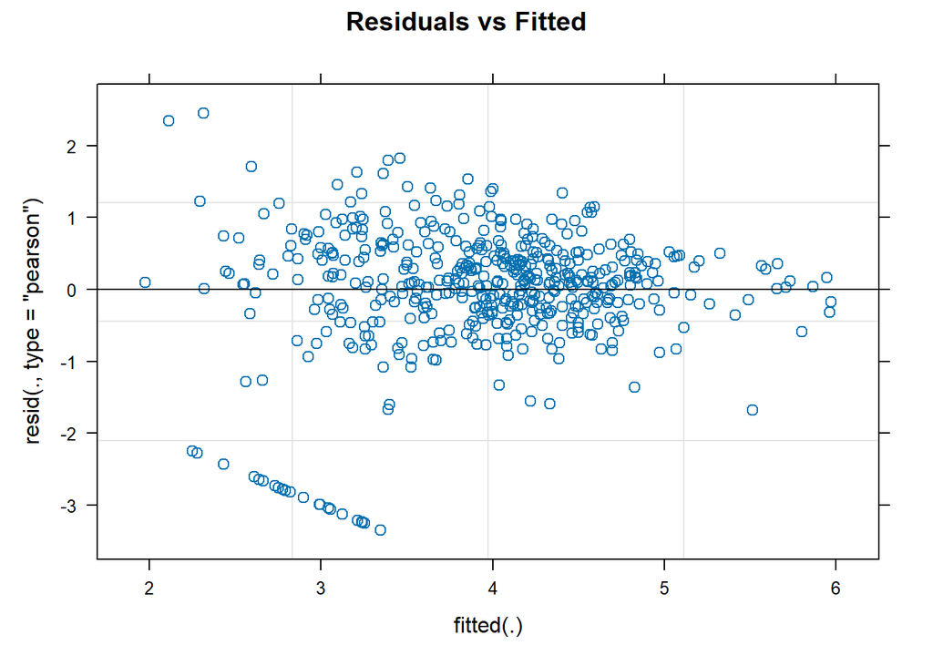

```r
plot(model_3, which = 1, main = "Residuals vs Fitted")
```

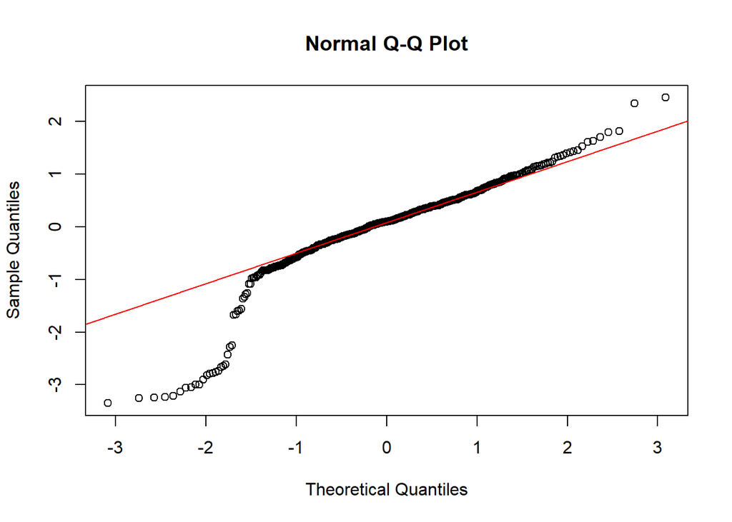

```r
qqnorm(residuals(model_3))
qqline(residuals(model_3), col = "red")
```

There is a systematic pattern of errors due to the presence of time = 0 observations violating the assumption of homoscedasticity (constant variance of errors)

The QQplot is completely skewed in lower values aswell residuals are NOT normally distributed.

Therefore results are unreliable

## Model Building test 2 - Dataset with removed 0 time instances

```r
model_full <- lmer(log(time+1) ~
                     condition * domain + num_characters + num_minor + num_major + MT_Quality + Difficulty +
                     (1 | PET) + (1 | text_name / Sent_id),
                   data = data_clean,
                   REML = FALSE)

summary(model_full)
```

```
## Linear mixed model fit by maximum likelihood . t-tests use Satterthwaite's
##   method [lmerModLmerTest]
## Formula: log(time + 1) ~ condition * domain + num_characters + num_minor +
##     num_major + MT_Quality + Difficulty + (1 | PET) + (1 | text_name/Sent_id)
##    Data: data_clean
##
##      AIC      BIC   logLik deviance df.resid
##    941.7   1012.4   -453.8    907.7      457
##
## Scaled residuals:
##     Min      1Q  Median      3Q     Max
## -3.2124 -0.5915  0.0179  0.6334  2.6118
##
## Random effects:
##  Groups            Name        Variance Std.Dev.
##  Sent_id:text_name (Intercept) 0.075744 0.27522
##  text_name         (Intercept) 0.009839 0.09919
##  PET               (Intercept) 0.058932 0.24276
##  Residual                      0.332375 0.57652
## Number of obs: 474, groups:  Sent_id:text_name, 62; text_name, 8; PET, 8
##
## Fixed effects:
##                         Estimate Std. Error         df t value Pr(>|t|)
## (Intercept)            3.867e+00  2.088e-01  8.726e+01  18.520  < 2e-16 ***
## condition2            -5.016e-01  1.359e-01  4.660e+02  -3.691 0.000250 ***
## condition3            -3.528e-01  1.237e-01  4.556e+02  -2.853 0.004526 **
## condition4            -2.290e-01  1.197e-01  4.526e+02  -1.913 0.056331 .
## domainnews            -5.170e-02  1.501e-01  1.935e+01  -0.344 0.734323
## num_characters         3.831e-03  5.019e-04  6.398e+01   7.633 1.43e-10 ***
## num_minor              5.208e-02  2.218e-02  3.435e+02   2.347 0.019475 *
## num_major              7.898e-02  4.566e-02  3.563e+02   1.730 0.084556 .
## MT_Quality            -1.563e-01  4.524e-02  4.001e+02  -3.455 0.000609 ***
## Difficulty             1.998e-02  3.788e-02  2.403e+02   0.527 0.598372
## condition2:domainnews  4.146e-01  1.562e-01  4.189e+02   2.655 0.008244 **
## condition3:domainnews  2.955e-01  1.519e-01  4.052e+02   1.945 0.052509 .
## condition4:domainnews  3.880e-02  1.514e-01  4.049e+02   0.256 0.797931
## ---
## Signif. codes:  0 '***' 0.001 '**' 0.01 '*' 0.05 '.' 0.1 ' ' 1
```

```
##
## Correlation matrix not shown by default, as p = 13 > 12.
## Use print(x, correlation=TRUE)  or
##     vcov(x)        if you need it
```

```r
model_2 <- lmer(log(time+1) ~
                     condition * domain + num_characters + num_minor + num_major + MT_Quality +
                     (1 | PET) + (1 | text_name / Sent_id),
                   data = data_clean,
                   REML = FALSE)

summary(model_2)
```

```
## Linear mixed model fit by maximum likelihood . t-tests use Satterthwaite's
##   method [lmerModLmerTest]
## Formula: log(time + 1) ~ condition * domain + num_characters + num_minor +
##     num_major + MT_Quality + (1 | PET) + (1 | text_name/Sent_id)
##    Data: data_clean
##
##      AIC      BIC   logLik deviance df.resid
##    939.9   1006.5   -454.0    907.9      458
##
## Scaled residuals:
##     Min      1Q  Median      3Q     Max
## -3.2190 -0.5847  0.0347  0.6160  2.6392
##
## Random effects:
##  Groups            Name        Variance Std.Dev.
##  Sent_id:text_name (Intercept) 0.075560 0.27488
##  text_name         (Intercept) 0.007986 0.08937
##  PET               (Intercept) 0.061051 0.24708
##  Residual                      0.332877 0.57696
## Number of obs: 474, groups:  Sent_id:text_name, 62; text_name, 8; PET, 8
##
## Fixed effects:
##                         Estimate Std. Error         df t value Pr(>|t|)
## (Intercept)            3.905e+00  1.976e-01  8.241e+01  19.758  < 2e-16 ***
## condition2            -4.918e-01  1.344e-01  4.670e+02  -3.659 0.000283 ***
## condition3            -3.437e-01  1.226e-01  4.535e+02  -2.803 0.005282 **
## condition4            -2.239e-01  1.193e-01  4.531e+02  -1.876 0.061230 .
## domainnews            -3.715e-02  1.445e-01  2.095e+01  -0.257 0.799567
## num_characters         3.815e-03  4.999e-04  6.460e+01   7.630 1.37e-10 ***
## num_minor              5.204e-02  2.217e-02  3.438e+02   2.347 0.019503 *
## num_major              7.846e-02  4.562e-02  3.558e+02   1.720 0.086359 .
## MT_Quality            -1.526e-01  4.417e-02  3.550e+02  -3.455 0.000618 ***
## condition2:domainnews  4.105e-01  1.561e-01  4.189e+02   2.630 0.008850 **
## condition3:domainnews  2.929e-01  1.520e-01  4.052e+02   1.927 0.054660 .
## condition4:domainnews  4.036e-02  1.515e-01  4.052e+02   0.266 0.790065
## ---
## Signif. codes:  0 '***' 0.001 '**' 0.01 '*' 0.05 '.' 0.1 ' ' 1
##
## Correlation of Fixed Effects:
##             (Intr) cndtn2 cndtn3 cndtn4 dmnnws nm_chr nm_mnr nm_mjr MT_Qlt
```

[output cut: 8 more lines]

```
## cndtn2:dmnn  0.221 -0.653 -0.401 -0.411 -0.520 -0.064  0.214 -0.008  0.002
## cndtn3:dmnn  0.152 -0.290 -0.620 -0.331 -0.532 -0.007 -0.005  0.040  0.083
## cndtn4:dmnn  0.179 -0.291 -0.323 -0.617 -0.537 -0.008 -0.013  0.038  0.039
##             cndt2: cndt3:
## condition2
## condition3
## condition4
## domainnews
## num_chrctrs
## num_minor
## num_major
## MT_Quality
## cndtn2:dmnn
## cndtn3:dmnn  0.492
## cndtn4:dmnn  0.494  0.515
```

```r
anova(model_full, model_2)
```

```
## Data: data_clean
## Models:
## model_2: log(time + 1) ~ condition * domain + num_characters + num_minor + num_major + MT_Quality + (1 | PET) + (1 | text_name/Sent_id)
## model_full: log(time + 1) ~ condition * domain + num_characters + num_minor + num_major + MT_Quality + Difficulty + (1 | PET) + (1 | text_name/Sent_id)
##            npar    AIC    BIC  logLik deviance  Chisq Df Pr(>Chisq)
## model_2      16 939.92 1006.5 -453.96   907.92
## model_full   17 941.67 1012.4 -453.83   907.67 0.2534  1     0.6147
```

```r
model_3 <- lmer(log(time+1) ~
                  condition * domain + num_characters + num_minor + num_major + MT_Quality +
                  (1 | PET) + (1 | text_name / Sent_id),
                data = data_clean,
                REML = TRUE)
summary(model_3)
```

```
## Linear mixed model fit by REML. t-tests use Satterthwaite's method [
## lmerModLmerTest]
## Formula: log(time + 1) ~ condition * domain + num_characters + num_minor +
##     num_major + MT_Quality + (1 | PET) + (1 | text_name/Sent_id)
##    Data: data_clean
##
## REML criterion at convergence: 958.3
##
## Scaled residuals:
##      Min       1Q   Median       3Q      Max
## -3.15972 -0.57416  0.02962  0.60064  2.60235
##
## Random effects:
##  Groups            Name        Variance Std.Dev.
##  Sent_id:text_name (Intercept) 0.07812  0.2795
##  text_name         (Intercept) 0.01386  0.1177
##  PET               (Intercept) 0.06894  0.2626
##  Residual                      0.33966  0.5828
## Number of obs: 474, groups:  Sent_id:text_name, 62; text_name, 8; PET, 8
##
## Fixed effects:
##                         Estimate Std. Error         df t value Pr(>|t|)
## (Intercept)            3.894e+00  2.060e-01  6.475e+01  18.902  < 2e-16 ***
## condition2            -4.882e-01  1.360e-01  4.558e+02  -3.589 0.000368 ***
## condition3            -3.439e-01  1.240e-01  4.437e+02  -2.774 0.005768 **
## condition4            -2.224e-01  1.206e-01  4.436e+02  -1.844 0.065901 .
## domainnews            -3.778e-02  1.557e-01  1.432e+01  -0.243 0.811688
## num_characters         3.823e-03  5.098e-04  6.224e+01   7.498 2.89e-10 ***
## num_minor              5.103e-02  2.246e-02  3.364e+02   2.271 0.023748 *
## num_major              7.798e-02  4.625e-02  3.478e+02   1.686 0.092707 .
## MT_Quality            -1.486e-01  4.498e-02  3.565e+02  -3.303 0.001054 **
## condition2:domainnews  4.098e-01  1.577e-01  4.110e+02   2.599 0.009693 **
## condition3:domainnews  2.948e-01  1.536e-01  3.976e+02   1.920 0.055606 .
## condition4:domainnews  4.144e-02  1.530e-01  3.977e+02   0.271 0.786711
## ---
## Signif. codes:  0 '***' 0.001 '**' 0.01 '*' 0.05 '.' 0.1 ' ' 1
##
## Correlation of Fixed Effects:
##             (Intr) cndtn2 cndtn3 cndtn4 dmnnws nm_chr nm_mnr nm_mjr MT_Qlt
## condition2  -0.341
## condition3  -0.187  0.620
## condition4  -0.284  0.643  0.627
## domainnews  -0.362  0.282  0.299  0.314
## num_chrctrs -0.435  0.195  0.149  0.154 -0.070
## num_minor    0.134 -0.570 -0.454 -0.458  0.013 -0.302
## num_major    0.043 -0.366 -0.232 -0.227  0.006 -0.167  0.331
## MT_Quality  -0.573  0.060 -0.206 -0.053  0.035  0.004  0.006  0.062
## cndtn2:dmnn  0.215 -0.652 -0.401 -0.411 -0.488 -0.064  0.214 -0.008  0.002
## cndtn3:dmnn  0.146 -0.290 -0.620 -0.330 -0.499 -0.007 -0.005  0.040  0.084
## cndtn4:dmnn  0.173 -0.291 -0.323 -0.616 -0.503 -0.008 -0.013  0.038  0.040
##             cndt2: cndt3:
## condition2
## condition3
## condition4
## domainnews
## num_chrctrs
## num_minor
## num_major
## MT_Quality
## cndtn2:dmnn
## cndtn3:dmnn  0.492
## cndtn4:dmnn  0.494  0.515
```

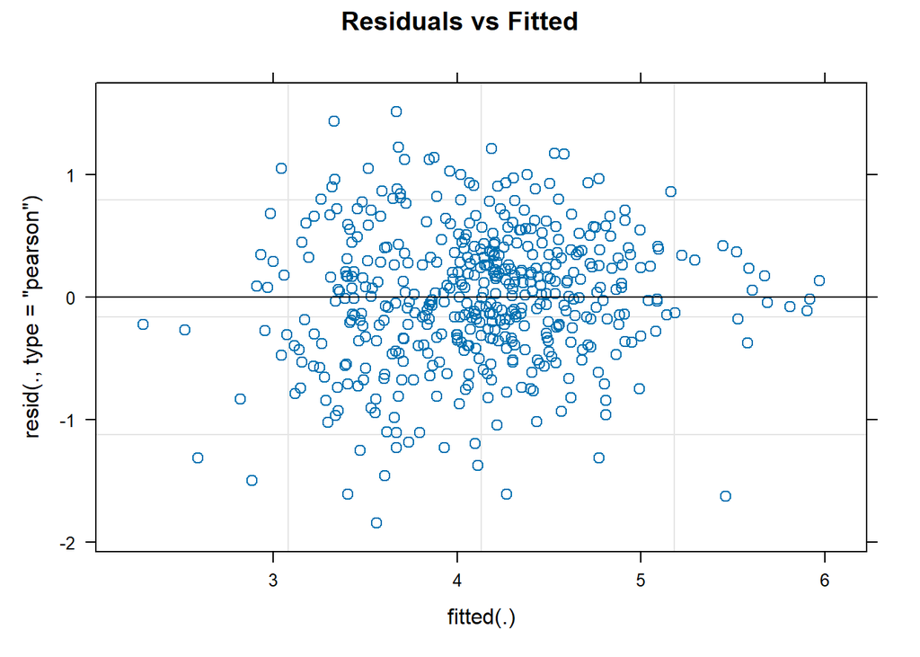

```r
plot(model_3, which = 1, main = "Residuals vs Fitted")
```

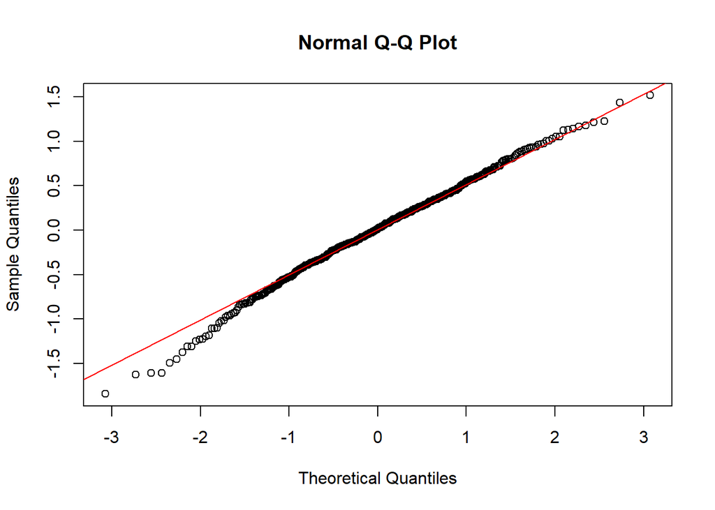

```r
qqnorm(residuals(model_3))
qqline(residuals(model_3), col = "red")
```

Assumptions checked, residuals are normally distributed

limit of this model is: removing zeros is CONCEPTUALLY WRONG as they are not MCAR (missing completely at random) this causes SELECTION BIAS

## Model Building test 3 (Option 1) - dataset with 0 time instances substituted with number of characters/20

Under the assumption a professional translator takes around 1 second to make sure 20 characters contain no errors and should not be edited.

```r
data_impute <- data
data_impute$time_fixed <- ifelse(data_impute$time == 0, data_impute$num_characters / 20, data_impute$time)
View(data_impute[data_impute$time == 0,])
```

```r
model_full <- lmer(log(time_fixed) ~
                     condition * domain + num_characters + num_minor + num_major + MT_Quality + Difficulty +
                     (1 | PET) + (1 | text_name / Sent_id),
                   data = data_impute,
                   REML = FALSE)
```

```
## boundary (singular) fit: see help('isSingular')
```

```r
# Singular Fit

model_2 <- lmer(log(time_fixed) ~
                     condition * domain + num_characters + num_minor + num_major + MT_Quality +
                     (1 | PET) + (1 | text_name : Sent_id),
                   data = data_impute,
                   REML = FALSE)

summary(model_2)
```

```
## Linear mixed model fit by maximum likelihood . t-tests use Satterthwaite's
##   method [lmerModLmerTest]
## Formula: log(time_fixed) ~ condition * domain + num_characters + num_minor +
##     num_major + MT_Quality + (1 | PET) + (1 | text_name:Sent_id)
##    Data: data_impute
##
##      AIC      BIC   logLik deviance df.resid
##   1173.0   1236.1   -571.5   1143.0      481
##
## Scaled residuals:
##     Min      1Q  Median      3Q     Max
## -3.2114 -0.5007  0.1237  0.5827  2.9960
##
## Random effects:
##  Groups            Name        Variance Std.Dev.
##  text_name:Sent_id (Intercept) 0.10706  0.3272
##  PET               (Intercept) 0.05395  0.2323
##  Residual                      0.50204  0.7085
## Number of obs: 496, groups:  text_name:Sent_id, 62; PET, 8
##
## Fixed effects:
##                         Estimate Std. Error         df t value Pr(>|t|)
## (Intercept)            3.539e+00  2.164e-01  1.473e+02  16.354  < 2e-16 ***
## condition2            -3.169e-01  1.546e-01  4.913e+02  -2.050 0.040909 *
## condition3            -1.066e-01  1.416e-01  4.725e+02  -0.753 0.451990
## condition4             1.699e-02  1.388e-01  4.735e+02   0.122 0.902571
## domainnews             1.944e-01  1.534e-01  2.236e+02   1.268 0.206144
## num_characters         4.747e-03  5.886e-04  6.705e+01   8.066 1.82e-11 ***
## num_minor              4.624e-02  2.646e-02  3.604e+02   1.747 0.081459 .
## num_major              6.528e-02  5.493e-02  3.629e+02   1.188 0.235452
## MT_Quality            -1.953e-01  5.134e-02  4.854e+02  -3.804 0.000161 ***
## condition2:domainnews  2.885e-01  1.851e-01  4.364e+02   1.559 0.119814
## condition3:domainnews  8.195e-02  1.809e-01  4.242e+02   0.453 0.650731
## condition4:domainnews -1.937e-01  1.807e-01  4.240e+02  -1.072 0.284349
## ---
## Signif. codes:  0 '***' 0.001 '**' 0.01 '*' 0.05 '.' 0.1 ' ' 1
##
## Correlation of Fixed Effects:
##             (Intr) cndtn2 cndtn3 cndtn4 dmnnws nm_chr nm_mnr nm_mjr MT_Qlt
## condition2  -0.352
## condition3  -0.187  0.601
## condition4  -0.295  0.622  0.599
## domainnews  -0.322  0.307  0.325  0.342
## num_chrctrs -0.470  0.189  0.137  0.141 -0.096
## num_minor    0.134 -0.567 -0.445 -0.449  0.030 -0.305
## num_major    0.032 -0.353 -0.217 -0.210  0.019 -0.167  0.315
## MT_Quality  -0.643  0.057 -0.198 -0.039  0.060  0.018  0.014  0.073
## cndtn2:dmnn  0.217 -0.629 -0.372 -0.381 -0.568 -0.054  0.200 -0.027 -0.002
## cndtn3:dmnn  0.150 -0.260 -0.598 -0.297 -0.583  0.006 -0.024  0.028  0.065
## cndtn4:dmnn  0.176 -0.266 -0.295 -0.601 -0.587  0.005 -0.023  0.029  0.027
##             cndt2: cndt3:
## condition2
## condition3
## condition4
## domainnews
## num_chrctrs
## num_minor
## num_major
## MT_Quality
## cndtn2:dmnn
## cndtn3:dmnn  0.478
## cndtn4:dmnn  0.480  0.501
```

```r
model_fixed <- lmer(log(time_fixed) ~
                      condition * domain + num_characters +
                      num_minor + num_major + MT_Quality +
                      (1 | PET) + (1 | text_name : Sent_id),
                    data = data_impute, REML = TRUE)

summary(model_fixed)
```

```
## Linear mixed model fit by REML. t-tests use Satterthwaite's method [
## lmerModLmerTest]
## Formula: log(time_fixed) ~ condition * domain + num_characters + num_minor +
##     num_major + MT_Quality + (1 | PET) + (1 | text_name:Sent_id)
##    Data: data_impute
##
## REML criterion at convergence: 1190.1
##
## Scaled residuals:
##     Min      1Q  Median      3Q     Max
## -3.1780 -0.4955  0.1155  0.5775  2.9801
##
## Random effects:
##  Groups            Name        Variance Std.Dev.
##  text_name:Sent_id (Intercept) 0.11493  0.3390
##  PET               (Intercept) 0.06149  0.2480
##  Residual                      0.51166  0.7153
## Number of obs: 496, groups:  text_name:Sent_id, 62; PET, 8
##
## Fixed effects:
##                         Estimate Std. Error         df t value Pr(>|t|)
## (Intercept)            3.535e+00  2.217e-01  1.264e+02  15.943  < 2e-16 ***
## condition2            -3.127e-01  1.564e-01  4.798e+02  -1.999 0.046134 *
## condition3            -1.041e-01  1.431e-01  4.627e+02  -0.727 0.467505
## condition4             1.956e-02  1.402e-01  4.638e+02   0.139 0.889117
## domainnews             1.943e-01  1.561e-01  2.087e+02   1.245 0.214594
## num_characters         4.756e-03  6.034e-04  6.406e+01   7.881  5.2e-11 ***
## num_minor              4.512e-02  2.686e-02  3.538e+02   1.680 0.093921 .
## num_major              6.402e-02  5.575e-02  3.563e+02   1.148 0.251560
## MT_Quality            -1.944e-01  5.199e-02  4.742e+02  -3.739 0.000207 ***
## condition2:domainnews  2.874e-01  1.869e-01  4.286e+02   1.538 0.124906
## condition3:domainnews  8.231e-02  1.826e-01  4.169e+02   0.451 0.652410
## condition4:domainnews -1.933e-01  1.825e-01  4.168e+02  -1.059 0.290065
## ---
## Signif. codes:  0 '***' 0.001 '**' 0.01 '*' 0.05 '.' 0.1 ' ' 1
##
## Correlation of Fixed Effects:
##             (Intr) cndtn2 cndtn3 cndtn4 dmnnws nm_chr nm_mnr nm_mjr MT_Qlt
## condition2  -0.348
## condition3  -0.184  0.602
## condition4  -0.292  0.623  0.600
## domainnews  -0.318  0.304  0.322  0.339
## num_chrctrs -0.471  0.188  0.136  0.141 -0.096
## num_minor    0.133 -0.570 -0.447 -0.451  0.030 -0.302
## num_major    0.033 -0.354 -0.218 -0.211  0.019 -0.165  0.316
## MT_Quality  -0.636  0.058 -0.198 -0.038  0.060  0.018  0.012  0.072
## cndtn2:dmnn  0.214 -0.629 -0.372 -0.381 -0.564 -0.054  0.201 -0.027 -0.002
## cndtn3:dmnn  0.148 -0.260 -0.597 -0.296 -0.578  0.006 -0.024  0.028  0.065
## cndtn4:dmnn  0.173 -0.265 -0.294 -0.600 -0.582  0.005 -0.023  0.029  0.027
##             cndt2: cndt3:
## condition2
## condition3
## condition4
## domainnews
## num_chrctrs
## num_minor
## num_major
## MT_Quality
## cndtn2:dmnn
## cndtn3:dmnn  0.477
## cndtn4:dmnn  0.479  0.501
```

Condition 2 effect is statistically significant in medical domain and lowers elapsed time by 27% compared to baseline.

### Effects Plots

```r
eff_int <- predict_response(model_fixed, terms = c("condition", "domain"))
```

```
## Model has log-transformed response. Back-transforming predictions to
##   original response scale. Standard errors are still on the transformed
```

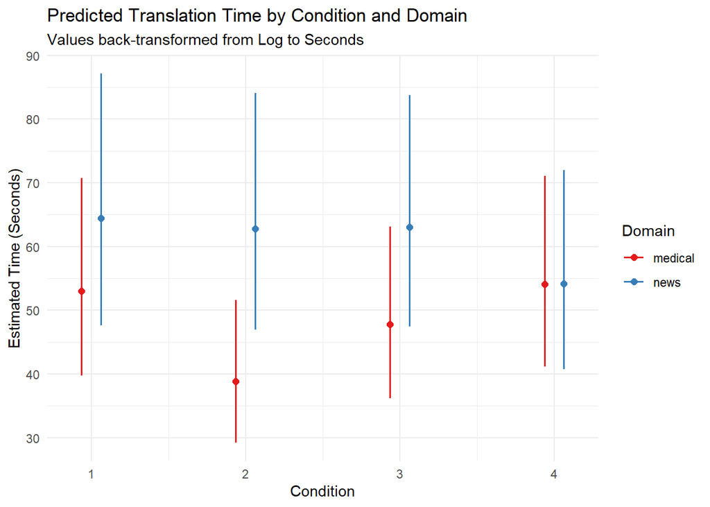

```r
plot(eff_int) +
  labs(
    title = "Predicted Translation Time by Condition and Domain",
    subtitle = "Values back-transformed from Log to Seconds",
    x = "Condition",
    y = "Estimated Time (Seconds)",
    colour = "Domain"
  ) +
  theme_minimal()
```

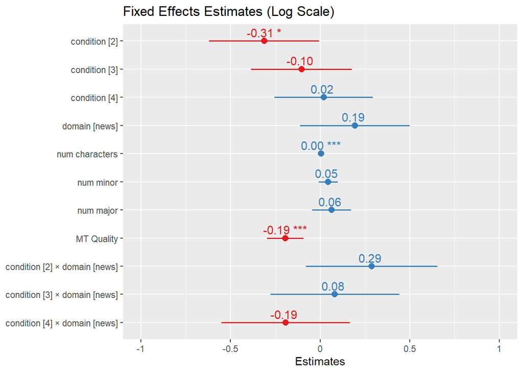

```r
plot_model(model_fixed,
           type = "est",
           show.values = TRUE,
           value.offset = .3,
           title = "Fixed Effects Estimates (Log Scale)")
```

```r
icc_results1 <- icc(model_fixed)

print(icc_results1) # Random effects account for 18% of total variance
```

```
## # Intraclass Correlation Coefficient
##
##     Adjusted ICC: 0.256
##   Unadjusted ICC: 0.177
```

```r
r2_results1 <- r2(model_fixed)

print(r2_results1) # 31% of total variance comes from fixed effects
```

```
## # R2 for Mixed Models
##
##   Conditional R2: 0.486
##      Marginal R2: 0.309
```

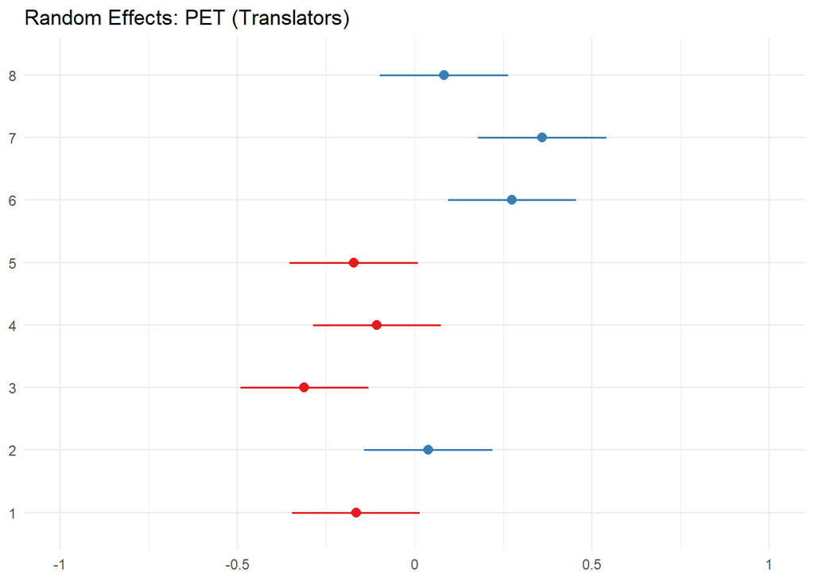

```r
# R2 is 49%

random_effects <- ranef(model_fixed)
plot_model(model_fixed, type = "re", grid = FALSE)[[2]] +
  theme_minimal() +
  labs(title = "Random Effects: PET (Translators)")
```

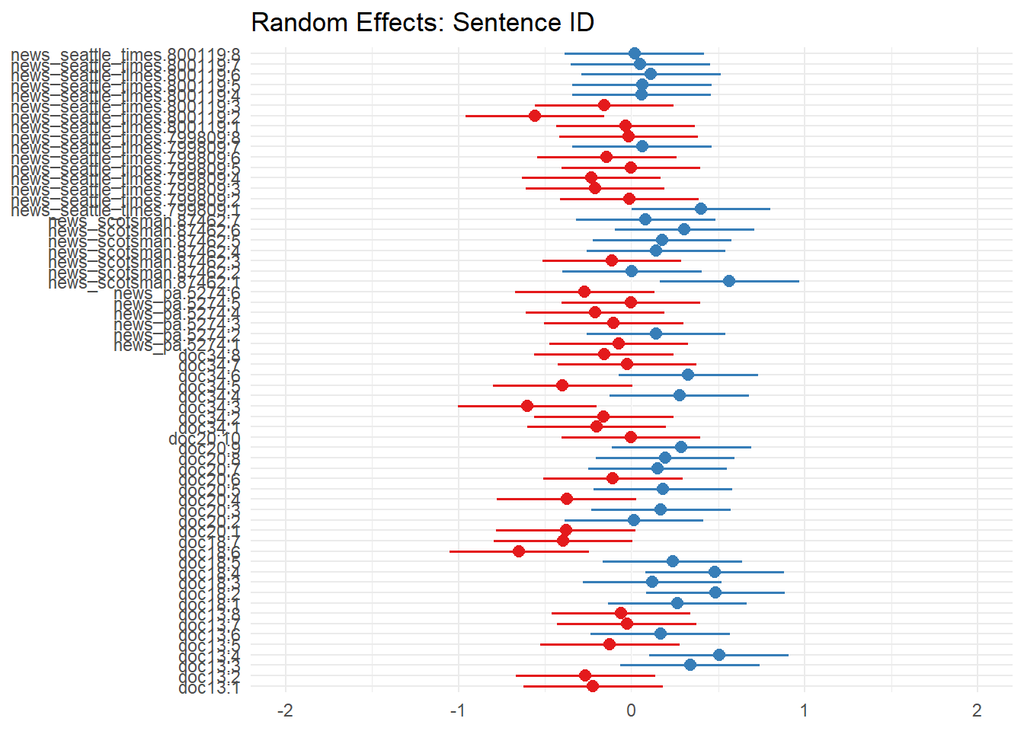

```r
plot_model(model_fixed, type = "re", grid = FALSE)[[1]] +
  theme_minimal() +
  labs(title = "Random Effects: Sentence ID")
```

### Assumptions Check

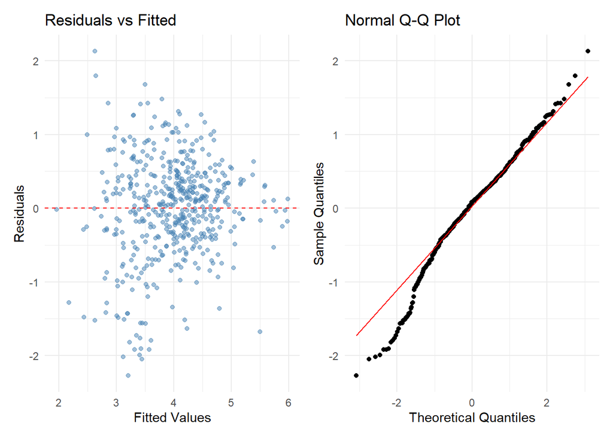

```r
diag_data <- data.frame(
  Fitted = fitted(model_fixed),
  Residuals = residuals(model_fixed)
)

d1 <- ggplot(diag_data, aes(x = Fitted, y = Residuals)) +
  geom_point(alpha = 0.5, color = "steelblue") +
  geom_hline(yintercept = 0, linetype = "dashed", color = "red") +
  labs(title = "Residuals vs Fitted",
       x = "Fitted Values",
       y = "Residuals") +
  theme_minimal()

d2 <- ggplot(diag_data, aes(sample = Residuals)) +
  stat_qq() +
  stat_qq_line(color = "red") +
  labs(title = "Normal Q-Q Plot",
       x = "Theoretical Quantiles",
       y = "Sample Quantiles") +
  theme_minimal()

d1+d2
```

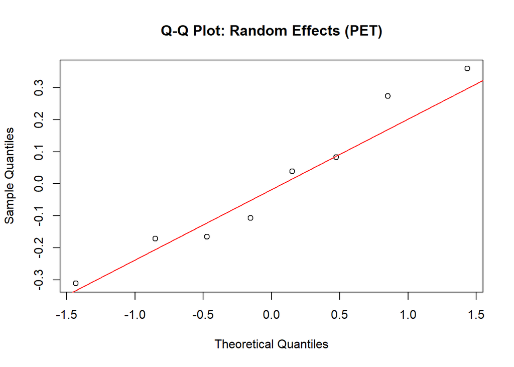

```r
pet_re <- ranef(model_fixed)$PET[,1]
qqnorm(pet_re, main = "Q-Q Plot: Random Effects (PET)")
qqline(pet_re, col = "red")
```

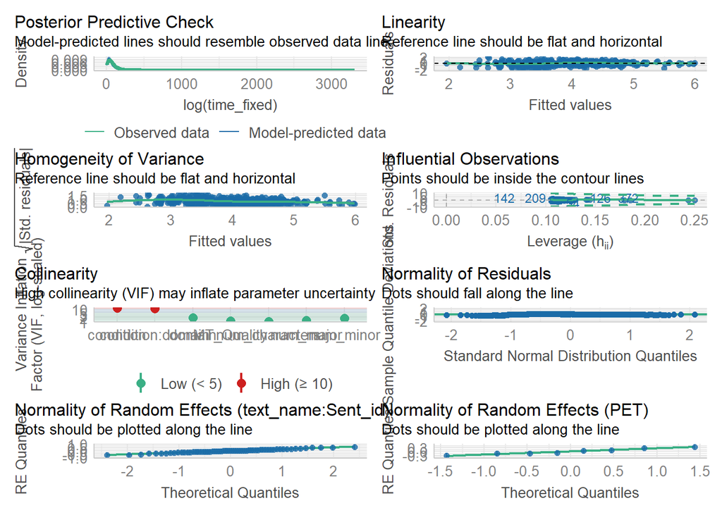

```r
check_model(model_fixed) # The high VIF does not distort the model's standard errors or the significance of our main findings, it can be safely ignored.
```

### Contrast Analysis - Switch of Baseline

```r
data_impute$condition <- relevel(as.factor(data_impute$condition), ref = "2")
model_fixed <- lmer(log(time_fixed) ~
                      condition * domain + num_characters +
                      num_minor + num_major + MT_Quality +
                      (1 | PET) + (1 | text_name : Sent_id),
                    data = data_impute, REML = TRUE)

summary(model_fixed)
```

```
## Linear mixed model fit by REML. t-tests use Satterthwaite's method [
## lmerModLmerTest]
## Formula: log(time_fixed) ~ condition * domain + num_characters + num_minor +
##     num_major + MT_Quality + (1 | PET) + (1 | text_name:Sent_id)
##    Data: data_impute
##
## REML criterion at convergence: 1190.1
##
## Scaled residuals:
##     Min      1Q  Median      3Q     Max
## -3.1780 -0.4955  0.1155  0.5775  2.9801
##
## Random effects:
##  Groups            Name        Variance Std.Dev.
##  text_name:Sent_id (Intercept) 0.11493  0.3390
##  PET               (Intercept) 0.06149  0.2480
##  Residual                      0.51166  0.7153
## Number of obs: 496, groups:  text_name:Sent_id, 62; PET, 8
##
## Fixed effects:
##                         Estimate Std. Error         df t value Pr(>|t|)
## (Intercept)            3.222e+00  2.224e-01  1.319e+02  14.486  < 2e-16 ***
## condition1             3.127e-01  1.564e-01  4.798e+02   1.999 0.046134 *
## condition3             2.087e-01  1.342e-01  4.432e+02   1.555 0.120573
## condition4             3.323e-01  1.297e-01  4.366e+02   2.563 0.010722 *
## domainnews             4.817e-01  1.625e-01  2.189e+02   2.964 0.003369 **
## num_characters         4.756e-03  6.034e-04  6.406e+01   7.881  5.2e-11 ***
## num_minor              4.512e-02  2.686e-02  3.538e+02   1.680 0.093921 .
## num_major              6.402e-02  5.575e-02  3.563e+02   1.148 0.251560
## MT_Quality            -1.944e-01  5.199e-02  4.742e+02  -3.739 0.000207 ***
## condition1:domainnews -2.874e-01  1.869e-01  4.286e+02  -1.538 0.124906
## condition3:domainnews -2.051e-01  1.890e-01  4.336e+02  -1.085 0.278320
## condition4:domainnews -4.807e-01  1.885e-01  4.327e+02  -2.550 0.011120 *
## ---
## Signif. codes:  0 '***' 0.001 '**' 0.01 '*' 0.05 '.' 0.1 ' ' 1
##
## Correlation of Fixed Effects:
##             (Intr) cndtn1 cndtn3 cndtn4 dmnnws nm_chr nm_mnr nm_mjr MT_Qlt
## condition1  -0.356
## condition3  -0.159  0.524
## condition4  -0.270  0.533  0.538
## domainnews  -0.363  0.431  0.375  0.398
## num_chrctrs -0.337 -0.188 -0.074 -0.075 -0.154
## num_minor   -0.268  0.570  0.187  0.199  0.261 -0.302
## num_major   -0.217  0.354  0.181  0.199 -0.013 -0.165  0.316
## MT_Quality  -0.593 -0.058 -0.278 -0.111  0.055  0.018  0.012  0.072
## cndtn1:dmnn  0.229 -0.629 -0.336 -0.346 -0.609  0.054 -0.201  0.027  0.002
## cndtn3:dmnn  0.192 -0.371 -0.655 -0.349 -0.608  0.059 -0.222  0.054  0.065
## cndtn4:dmnn  0.213 -0.367 -0.337 -0.662 -0.611  0.058 -0.222  0.055  0.028
##             cndt1: cndt3:
## condition1
## condition3
## condition4
## domainnews
## num_chrctrs
## num_minor
## num_major
## MT_Quality
## cndtn1:dmnn
## cndtn3:dmnn  0.528
## cndtn4:dmnn  0.528  0.533
```

## Model Building test 4 (Option 2) - dataset with instances with time = 0 substituted with newly proposed times

### Dataset Loading + Merging

```r
data_time <- read_csv("data/data_time.csv")
View(data_time)

indices_zeros <- which(data$time == 0)

data$time_hybrid <- data$time
data$time_hybrid[indices_zeros] <- data_time$time

data_clean2 <- data[data$time_hybrid>1,] # There are only 3 instances still with unrealistic values, all in different condition groups, can assume they are MCAR
```

```r
model_hyb <- lmer(log(time_hybrid) ~
                     condition * domain + num_characters + num_minor + num_major + MT_Quality + Difficulty +
                     (1 | PET) + (1 | text_name / Sent_id),
                   data = data_clean2,
                   REML = FALSE)

summary(model_hyb)
```

```
## Linear mixed model fit by maximum likelihood . t-tests use Satterthwaite's
##   method [lmerModLmerTest]
## Formula: log(time_hybrid) ~ condition * domain + num_characters + num_minor +
##     num_major + MT_Quality + Difficulty + (1 | PET) + (1 | text_name/Sent_id)
##    Data: data_clean2
##
##      AIC      BIC   logLik deviance df.resid
##   1033.6   1105.0   -499.8    999.6      476
##
## Scaled residuals:
##     Min      1Q  Median      3Q     Max
## -3.3262 -0.5700  0.0267  0.6238  2.5081
##
## Random effects:
##  Groups            Name        Variance Std.Dev.
##  Sent_id:text_name (Intercept) 0.07683  0.2772
##  text_name         (Intercept) 0.01040  0.1020
##  PET               (Intercept) 0.05578  0.2362
##  Residual                      0.37734  0.6143
## Number of obs: 493, groups:  Sent_id:text_name, 62; text_name, 8; PET, 8
##
## Fixed effects:
##                         Estimate Std. Error         df t value Pr(>|t|)
## (Intercept)             3.795158   0.211945  87.060993  17.906  < 2e-16 ***
## condition2             -0.537575   0.137378 485.468933  -3.913 0.000104 ***
## condition3             -0.391636   0.124993 471.718067  -3.133 0.001836 **
## condition4             -0.332399   0.121492 470.126147  -2.736 0.006455 **
## domainnews             -0.108422   0.153322  19.090983  -0.707 0.488015
## num_characters          0.003894   0.000513  65.595071   7.591 1.48e-10 ***
## num_minor               0.051112   0.023059 347.515301   2.217 0.027300 *
## num_major               0.083338   0.047836 359.638300   1.742 0.082335 .
## MT_Quality             -0.142150   0.046609 418.306522  -3.050 0.002435 **
## Difficulty              0.038625   0.039239 221.839859   0.984 0.326021
## condition2:domainnews   0.453757   0.161404 435.067810   2.811 0.005157 **
## condition3:domainnews   0.346781   0.157453 422.437874   2.202 0.028174 *
## condition4:domainnews   0.153573   0.157053 422.230509   0.978 0.328712
## ---
## Signif. codes:  0 '***' 0.001 '**' 0.01 '*' 0.05 '.' 0.1 ' ' 1
```

```
##
## Correlation matrix not shown by default, as p = 13 > 12.
## Use print(x, correlation=TRUE)  or
##     vcov(x)        if you need it
```

```r
model_hyb2 <- lmer(log(time_hybrid) ~
                  condition * domain + num_characters + num_minor + num_major + MT_Quality +
                  (1 | PET) + (1 | text_name : Sent_id),
                data = data_clean2,
                REML = FALSE)

summary(model_hyb2)
```

```
## Linear mixed model fit by maximum likelihood . t-tests use Satterthwaite's
##   method [lmerModLmerTest]
## Formula: log(time_hybrid) ~ condition * domain + num_characters + num_minor +
##     num_major + MT_Quality + (1 | PET) + (1 | text_name:Sent_id)
##    Data: data_clean2
##
##      AIC      BIC   logLik deviance df.resid
##   1030.9   1093.9   -500.4   1000.9      478
##
## Scaled residuals:
##     Min      1Q  Median      3Q     Max
## -3.3673 -0.5801  0.0145  0.6177  2.5040
##
## Random effects:
##  Groups            Name        Variance Std.Dev.
##  text_name:Sent_id (Intercept) 0.08269  0.2876
##  PET               (Intercept) 0.05830  0.2415
##  Residual                      0.37883  0.6155
## Number of obs: 493, groups:  text_name:Sent_id, 62; PET, 8
##
## Fixed effects:
##                         Estimate Std. Error         df t value Pr(>|t|)
## (Intercept)            3.889e+00  1.949e-01  1.159e+02  19.953  < 2e-16 ***
## condition2            -5.233e-01  1.361e-01  4.873e+02  -3.846 0.000136 ***
## condition3            -3.734e-01  1.242e-01  4.706e+02  -3.007 0.002780 **
## condition4            -3.233e-01  1.213e-01  4.718e+02  -2.666 0.007938 **
## domainnews            -8.237e-02  1.340e-01  2.237e+02  -0.615 0.539442
## num_characters         3.845e-03  5.151e-04  6.786e+01   7.465 2.07e-10 ***
## num_minor              5.152e-02  2.314e-02  3.611e+02   2.226 0.026601 *
## num_major              8.143e-02  4.790e-02  3.647e+02   1.700 0.089968 .
## MT_Quality            -1.411e-01  4.490e-02  4.882e+02  -3.143 0.001773 **
## condition2:domainnews  4.495e-01  1.616e-01  4.352e+02   2.781 0.005654 **
## condition3:domainnews  3.423e-01  1.577e-01  4.224e+02   2.170 0.030547 *
## condition4:domainnews  1.567e-01  1.573e-01  4.223e+02   0.996 0.319696
## ---
## Signif. codes:  0 '***' 0.001 '**' 0.01 '*' 0.05 '.' 0.1 ' ' 1
##
## Correlation of Fixed Effects:
##             (Intr) cndtn2 cndtn3 cndtn4 dmnnws nm_chr nm_mnr nm_mjr MT_Qlt
## condition2  -0.345
## condition3  -0.185  0.603
## condition4  -0.289  0.625  0.602
## domainnews  -0.314  0.308  0.327  0.345
## num_chrctrs -0.458  0.191  0.137  0.143 -0.094
## num_minor    0.134 -0.573 -0.448 -0.453  0.027 -0.305
## num_major    0.034 -0.356 -0.219 -0.213  0.017 -0.167  0.318
## MT_Quality  -0.623  0.060 -0.195 -0.039  0.059  0.018  0.010  0.070
## cndtn2:dmnn  0.214 -0.633 -0.376 -0.386 -0.567 -0.057  0.207 -0.022 -0.004
## cndtn3:dmnn  0.147 -0.262 -0.601 -0.300 -0.582  0.006 -0.020  0.029  0.065
## cndtn4:dmnn  0.172 -0.267 -0.297 -0.602 -0.586  0.004 -0.021  0.031  0.028
##             cndt2: cndt3:
## condition2
## condition3
## condition4
## domainnews
## num_chrctrs
## num_minor
## num_major
## MT_Quality
## cndtn2:dmnn
## cndtn3:dmnn  0.477
## cndtn4:dmnn  0.480  0.502
```

```r
model_hyb3 <- lmer(log(time_hybrid) ~
                  condition * domain + num_characters + num_minor + num_major + MT_Quality +
                  (1 | PET) + (1 | text_name : Sent_id),
                data = data_clean2,
                REML = TRUE)
summary(model_hyb3)
```

```
## Linear mixed model fit by REML. t-tests use Satterthwaite's method [
## lmerModLmerTest]
## Formula: log(time_hybrid) ~ condition * domain + num_characters + num_minor +
##     num_major + MT_Quality + (1 | PET) + (1 | text_name:Sent_id)
##    Data: data_clean2
##
## REML criterion at convergence: 1051
##
## Scaled residuals:
##     Min      1Q  Median      3Q     Max
## -3.3263 -0.5659  0.0167  0.6132  2.4830
##
## Random effects:
##  Groups            Name        Variance Std.Dev.
##  text_name:Sent_id (Intercept) 0.08849  0.2975
##  PET               (Intercept) 0.06643  0.2577
##  Residual                      0.38621  0.6215
## Number of obs: 493, groups:  text_name:Sent_id, 62; PET, 8
##
## Fixed effects:
##                         Estimate Std. Error         df t value Pr(>|t|)
## (Intercept)            3.885e+00  2.001e-01  9.629e+01  19.414  < 2e-16 ***
## condition2            -5.206e-01  1.377e-01  4.759e+02  -3.782 0.000176 ***
## condition3            -3.719e-01  1.255e-01  4.608e+02  -2.963 0.003203 **
## condition4            -3.217e-01  1.226e-01  4.619e+02  -2.624 0.008984 **
## domainnews            -8.244e-02  1.363e-01  2.095e+02  -0.605 0.546038
## num_characters         3.851e-03  5.278e-04  6.494e+01   7.297 5.19e-10 ***
## num_minor              5.076e-02  2.348e-02  3.542e+02   2.162 0.031323 *
## num_major              8.088e-02  4.860e-02  3.579e+02   1.664 0.096955 .
## MT_Quality            -1.401e-01  4.545e-02  4.766e+02  -3.082 0.002175 **
## condition2:domainnews  4.487e-01  1.632e-01  4.273e+02   2.749 0.006237 **
## condition3:domainnews  3.427e-01  1.593e-01  4.150e+02   2.152 0.031984 *
## condition4:domainnews  1.571e-01  1.588e-01  4.149e+02   0.989 0.323077
## ---
## Signif. codes:  0 '***' 0.001 '**' 0.01 '*' 0.05 '.' 0.1 ' ' 1
##
## Correlation of Fixed Effects:
##             (Intr) cndtn2 cndtn3 cndtn4 dmnnws nm_chr nm_mnr nm_mjr MT_Qlt
## condition2  -0.341
## condition3  -0.182  0.603
## condition4  -0.285  0.626  0.603
## domainnews  -0.310  0.305  0.324  0.342
## num_chrctrs -0.457  0.189  0.136  0.142 -0.095
## num_minor    0.134 -0.575 -0.450 -0.454  0.027 -0.302
## num_major    0.035 -0.358 -0.220 -0.214  0.017 -0.166  0.319
## MT_Quality  -0.615  0.061 -0.194 -0.039  0.058  0.018  0.008  0.069
## cndtn2:dmnn  0.211 -0.633 -0.376 -0.387 -0.563 -0.056  0.208 -0.022 -0.004
## cndtn3:dmnn  0.145 -0.262 -0.601 -0.300 -0.577  0.006 -0.021  0.029  0.065
## cndtn4:dmnn  0.169 -0.267 -0.297 -0.602 -0.582  0.004 -0.021  0.031  0.028
##             cndt2: cndt3:
## condition2
## condition3
## condition4
## domainnews
## num_chrctrs
## num_minor
## num_major
## MT_Quality
## cndtn2:dmnn
## cndtn3:dmnn  0.477
## cndtn4:dmnn  0.480  0.502
```

### Effects Plots

```r
eff_int_hyb <- predict_response(model_hyb3, terms = c("condition", "domain"))
```

```
## Model has log-transformed response. Back-transforming predictions to
##   original response scale. Standard errors are still on the transformed
```

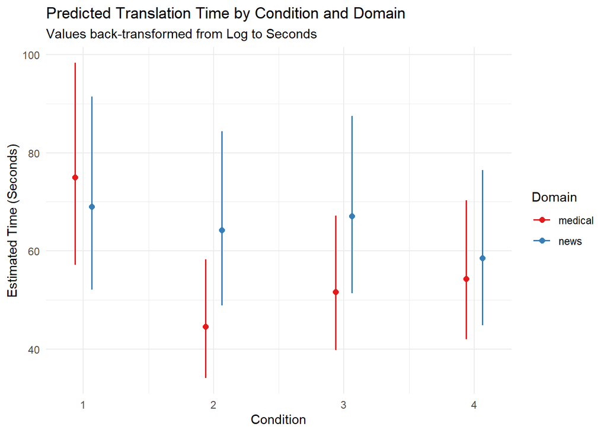

```r
plot(eff_int_hyb) +
  labs(
    title = "Predicted Translation Time by Condition and Domain",
    subtitle = "Values back-transformed from Log to Seconds",
    x = "Condition",
    y = "Estimated Time (Seconds)",
    colour = "Domain"
  ) +
  theme_minimal()
```

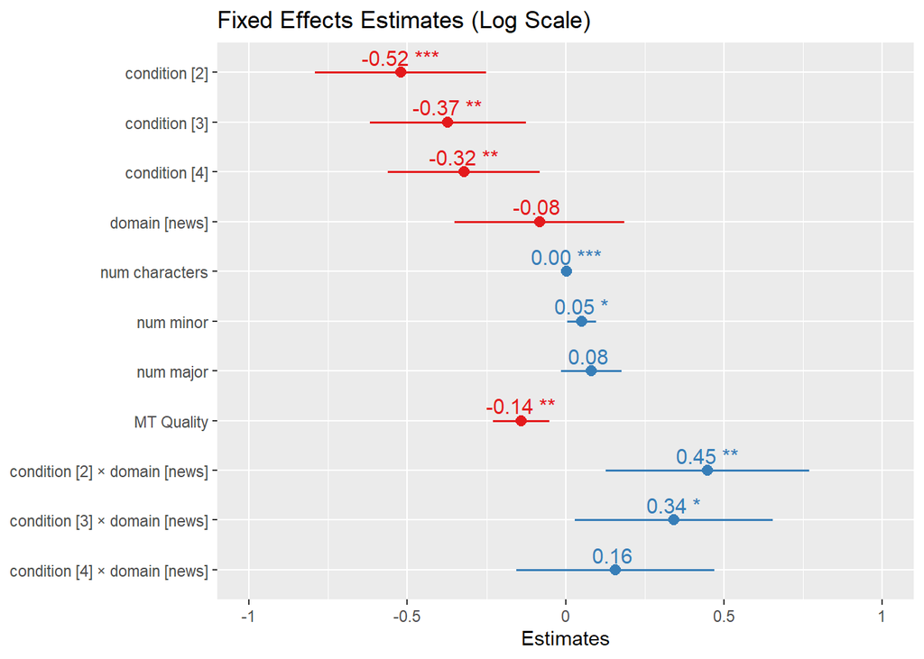

```r
plot_model(model_hyb3,
           type = "est",
           show.values = TRUE,
           value.offset = .3,
           title = "Fixed Effects Estimates (Log Scale)")
```

```r
icc_results2 <- icc(model_hyb3)

print(icc_results2) #random part accounts for 21% of total variance
```

```
## # Intraclass Correlation Coefficient
##
##     Adjusted ICC: 0.286
##   Unadjusted ICC: 0.206
```

```r
r2_results2 <- r2(model_hyb3) # fixed effects are 28% of total variance

print(r2_results2)
```

```
## # R2 for Mixed Models
##
##   Conditional R2: 0.486
##      Marginal R2: 0.279
```

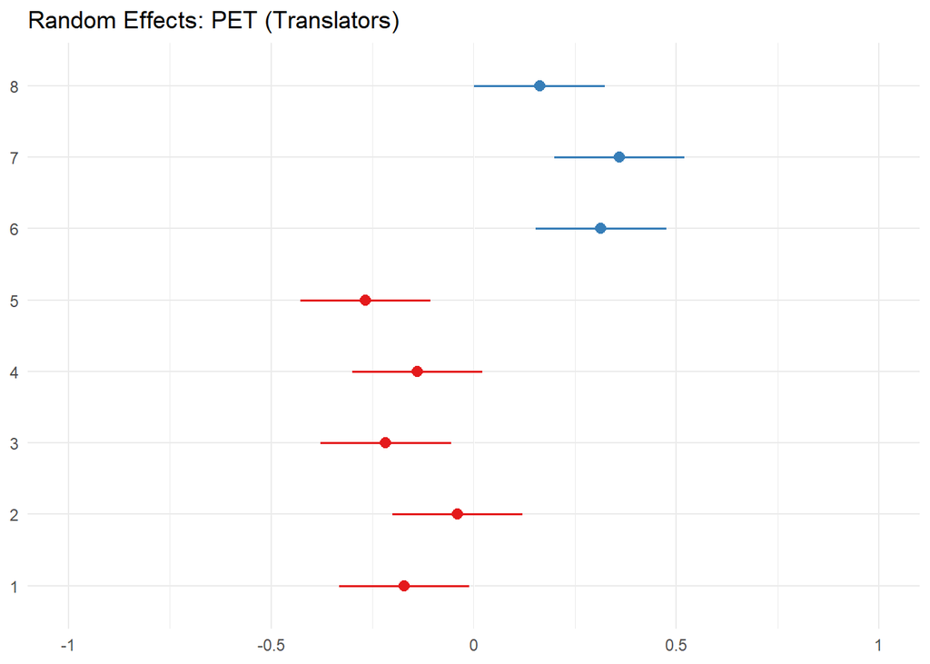

```r
# R2 is 49%

random_effects <- ranef(model_hyb3)
plot_model(model_hyb3, type = "re", grid = FALSE)[[2]] +
  theme_minimal() +
  labs(title = "Random Effects: PET (Translators)")
```

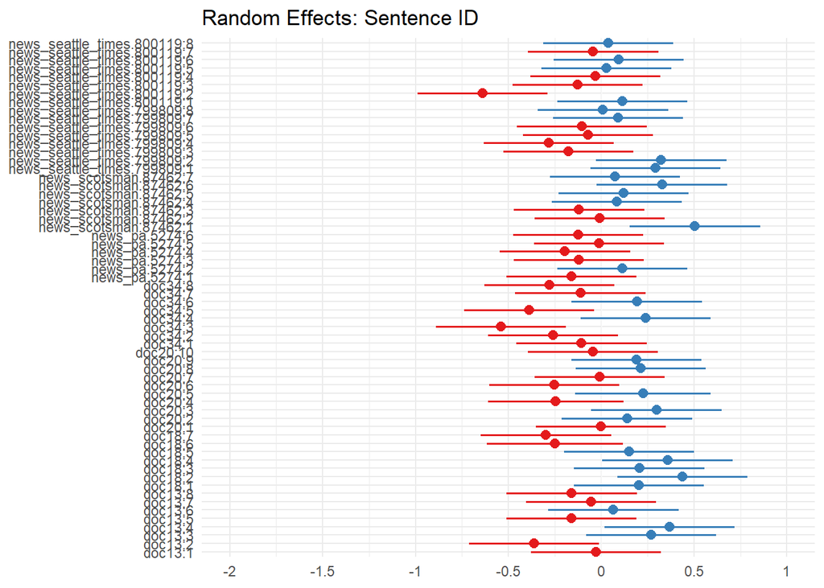

```r
plot_model(model_hyb3, type = "re", grid = FALSE)[[1]] +
  theme_minimal() +
  labs(title = "Random Effects: Sentence ID")
```

### Assumptions Check

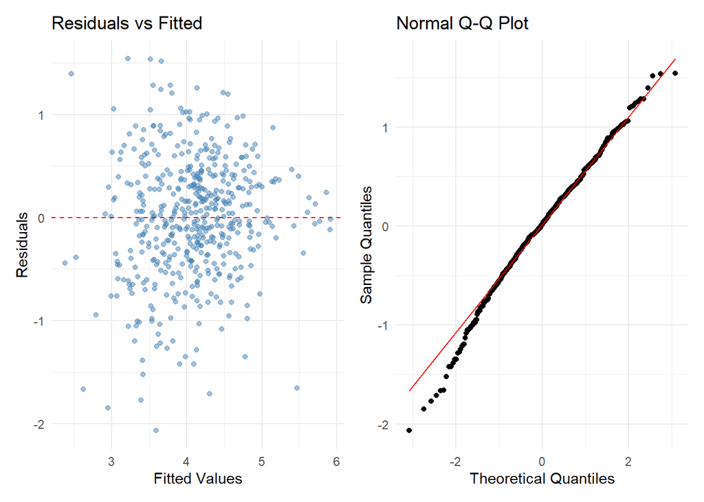

```r
diag_data <- data.frame(
  Fitted = fitted(model_hyb3),
  Residuals = residuals(model_hyb3)
)

d1 <- ggplot(diag_data, aes(x = Fitted, y = Residuals)) +
  geom_point(alpha = 0.5, color = "steelblue") +
  geom_hline(yintercept = 0, linetype = "dashed", color = "red") +
  labs(title = "Residuals vs Fitted",
       x = "Fitted Values",
       y = "Residuals") +
  theme_minimal()

d2 <- ggplot(diag_data, aes(sample = Residuals)) +
  stat_qq() +
  stat_qq_line(color = "red") +
  labs(title = "Normal Q-Q Plot",
       x = "Theoretical Quantiles",
       y = "Sample Quantiles") +
  theme_minimal()

d1+d2
```

```r
# residuals are normally distributed
```

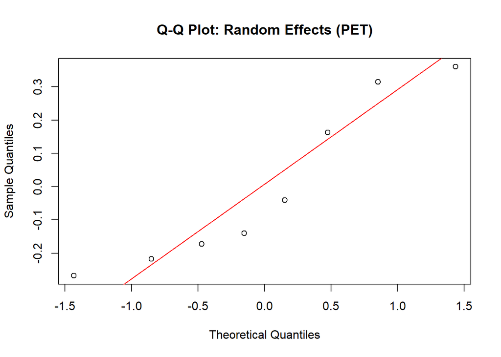

```r
pet_re <- ranef(model_hyb3)$PET[,1]
qqnorm(pet_re, main = "Q-Q Plot: Random Effects (PET)")
qqline(pet_re, col = "red")
```

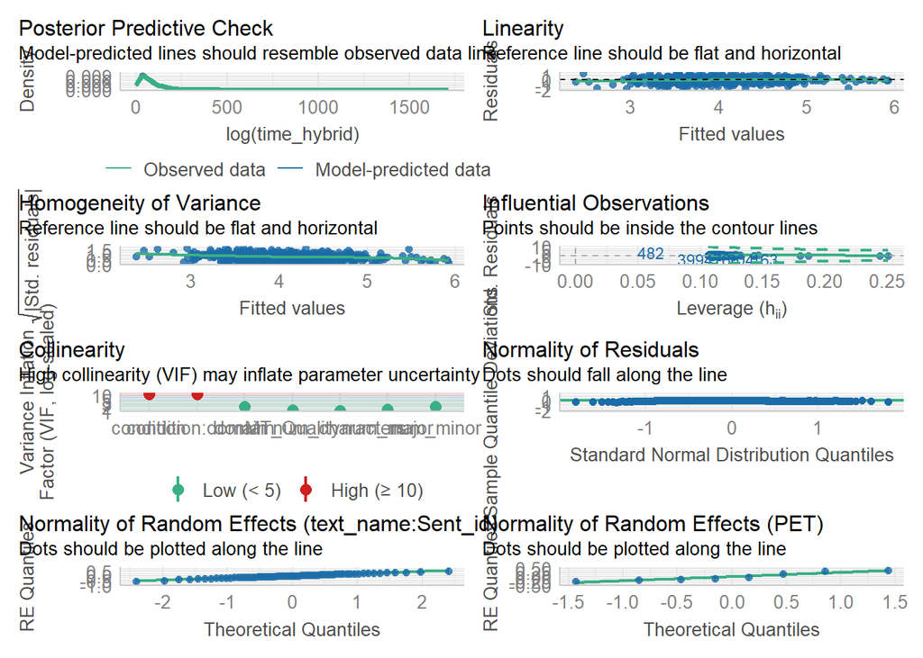

```r
check_model(model_hyb3) # The high VIF does not distort the model's standard errors or the significance of our main findings, it can be safely ignored.
```

Limit of this analysis is that the newly imputed times are measured differently than the originals they may be affected by external factors, such as translator taking breaks, and longer time to actually start the task.

### Contrast Analysis - Switch of Baseline

```r
data_clean2$condition <- relevel(as.factor(data_clean2$condition), ref = "2")
model_hyb3 <- lmer(log(time_hybrid) ~
                     condition * domain + num_characters + num_minor + num_major + MT_Quality +
                     (1 | PET)+ (1 | text_name : Sent_id),
                   data = data_clean2,
                   REML = TRUE)
summary(model_hyb3)
```

```
## Linear mixed model fit by REML. t-tests use Satterthwaite's method [
## lmerModLmerTest]
## Formula: log(time_hybrid) ~ condition * domain + num_characters + num_minor +
##     num_major + MT_Quality + (1 | PET) + (1 | text_name:Sent_id)
##    Data: data_clean2
##
## REML criterion at convergence: 1051
##
## Scaled residuals:
##     Min      1Q  Median      3Q     Max
## -3.3263 -0.5659  0.0167  0.6132  2.4830
##
## Random effects:
##  Groups            Name        Variance Std.Dev.
##  text_name:Sent_id (Intercept) 0.08849  0.2975
##  PET               (Intercept) 0.06643  0.2577
##  Residual                      0.38621  0.6215
## Number of obs: 493, groups:  text_name:Sent_id, 62; PET, 8
##
## Fixed effects:
##                         Estimate Std. Error         df t value Pr(>|t|)
## (Intercept)            3.365e+00  2.006e-01  9.932e+01  16.777  < 2e-16 ***
## condition1             5.206e-01  1.377e-01  4.759e+02   3.782 0.000176 ***
## condition3             1.486e-01  1.177e-01  4.393e+02   1.263 0.207335
## condition4             1.989e-01  1.134e-01  4.343e+02   1.754 0.080059 .
## domainnews             3.662e-01  1.421e-01  2.204e+02   2.577 0.010613 *
## num_characters         3.851e-03  5.278e-04  6.494e+01   7.297 5.19e-10 ***
## num_minor              5.076e-02  2.348e-02  3.542e+02   2.162 0.031323 *
## num_major              8.088e-02  4.860e-02  3.579e+02   1.664 0.096955 .
## MT_Quality            -1.401e-01  4.545e-02  4.766e+02  -3.082 0.002175 **
## condition1:domainnews -4.487e-01  1.632e-01  4.273e+02  -2.749 0.006237 **
## condition3:domainnews -1.059e-01  1.649e-01  4.309e+02  -0.642 0.521006
## condition4:domainnews -2.915e-01  1.643e-01  4.306e+02  -1.775 0.076675 .
## ---
## Signif. codes:  0 '***' 0.001 '**' 0.01 '*' 0.05 '.' 0.1 ' ' 1
##
## Correlation of Fixed Effects:
##             (Intr) cndtn1 cndtn3 cndtn4 dmnnws nm_chr nm_mnr nm_mjr MT_Qlt
## condition1  -0.346
## condition3  -0.157  0.526
## condition4  -0.264  0.537  0.542
## domainnews  -0.353  0.434  0.379  0.402
## num_chrctrs -0.326 -0.189 -0.077 -0.076 -0.156
## num_minor   -0.261  0.575  0.193  0.206  0.265 -0.302
## num_major   -0.211  0.358  0.184  0.203 -0.010 -0.166  0.319
## MT_Quality  -0.571 -0.061 -0.279 -0.116  0.052  0.018  0.008  0.069
## cndtn1:dmnn  0.224 -0.633 -0.339 -0.351 -0.609  0.056 -0.208  0.022  0.004
## cndtn3:dmnn  0.188 -0.374 -0.659 -0.353 -0.608  0.061 -0.226  0.050  0.066
## cndtn4:dmnn  0.209 -0.371 -0.341 -0.664 -0.612  0.059 -0.227  0.052  0.031
##             cndt1: cndt3:
## condition1
## condition3
## condition4
## domainnews
## num_chrctrs
## num_minor
## num_major
## MT_Quality
## cndtn1:dmnn
## cndtn3:dmnn  0.529
## cndtn4:dmnn  0.530  0.535
```